# Week Three: Summarizing & Visualizing Numerical Data

Welcome!

In this week’s coursework we are going to continuing exploring data, through data summaries and visualizations, focusing specifically on **numerical** variables. We will be using the **dplyr** package in `R` to wrangle our data and the **ggplot2** package to created data visualizations.

## Learning Outcomes

By the end of this coursework you should be able to:

- outline the differences between numerical and categorical variables
- describe what type of summary statistic is appropriate for a given  
  distribution of a numerical variable
- discuss when it is / is not appropriate to summarize a variable with a mean
- create visualizations of one and two numerical variables
- discuss the benefits and shortcomings of different visualizations

## This Week’s TODOs

📖 Reading: 30-45 minutes

💻 Tutorials: 60-75 minutes

✅ Check-ins: 2 (submit on Canvas)

# Exploring Numerical Data

📖 [**Required Reading:** Exploring Numerical Data](https://openintro-ims.netlify.app/explore-numerical.html)

💻 [**Required Tutorial:** Summarizing with Statistics](https://openintro.shinyapps.io/ims-02-explore-03/)

💻 [**Required Tutorial:** Exploring Numerical Data](https://openintro.shinyapps.io/ims-02-explore-02/)

If you are feeling like you would like to see additional materials on wrangling data and creating data visualizations in `R`, the *Modern Dive* textbook has two exellent chapters you can reference.

📖 [**Supplementary Reading:** Data Visualization](https://moderndive.com/2-viz.html)

📖 [**Supplementary Reading:** Data Visualization](https://moderndive.com/3-wrangling.html)

✅ **Check-in: Visualizing Numerical Data**

1. What aesthetics are being used in the following plot?

Hint: Think about what goes inside of the `aes()` function and what does not.

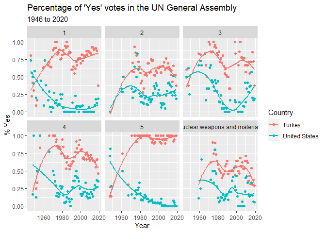

- `x` axis
- `y` axis
- `color`
- `facet`s
- `fill`
- `point`s
- `line`s